# STAT/MATH 495: Problem Set 05

Tasheena, Meron, Wayne

2017-10-11

# Collaboration:

Please indicate who you collaborated with on this assignment: -

# Exploratory Data Analysis

For this competition, participants were asked to combine historical usage patterns with weather data in order to forecast bike rental demand in the Capital Bike share program in Washington, D.C.

Our task is to use three variables to predict demand for bike rentals.

Information on the competition can be found [here](https://www.kaggle.com/c/bike-sharing-demand).

Table with variable description

| Variable | Description |
| --- | --- |
| datetime | hourly date + timestamp |
| season | 1 = spring, 2 = summer, 3 = fall, 4 = winter |
| holiday | whether the day is considered a holiday |
| workingday | whether the day is neither a weekend nor holiday |
| weather: |  |
|  | 1: Clear, Few clouds, Partly cloudy |
|  | 2: Mist + Cloudy, Mist + Broken clouds, Mist + Few clouds, Mist |
|  | 3: Light Snow, Light Rain + Thunderstorm + Scattered clouds, Light Rain + Scattered clouds |
|  | 4: Heavy Rain + Ice Pallets + Thunderstorm + Mist, Snow + Fog |
| temp | temperature in Celsius |
| atemp | ‘feels like’ temperature in Celsius |
| humidity | relative humidity |
| windspeed | wind speed |
| casual | number of non-registered user rentals initiated |
| registered | number of registered user rentals initiated |
| count | number of total rentals |

We have decided to use the variable ‘count’ as our response variable to take into account both registered users and those not registered. We have created three variables (month, hour, and wday) from the ‘datetime’ variable to analyze how month, hour and weekday affect the number of bikes checked out.

```r
# creating new variables: month, weekday, and hour for the train set
# we won't need year, min and second because second and minute are not valuable info and we only have two years worth of data
train <- train %>%
  mutate(datetime_new = ymd_hms(datetime)) %>%
  mutate(
    month = month(datetime_new), # month in which the bike was checked out
    hour = hour(datetime_new), # hour of the day the bike was checked out
    wday = wday(datetime_new) # weekday ranging from 1:7 where 1 is Sunday and 7, Saturday and the sequence ordered
  )
```

For our EDA, we looked at the distribution of count, and how the timestamp and weather affect the demand for bike rentals.

By observing the histogram below, we can see that the our variable ‘count’ is highly right skewed.

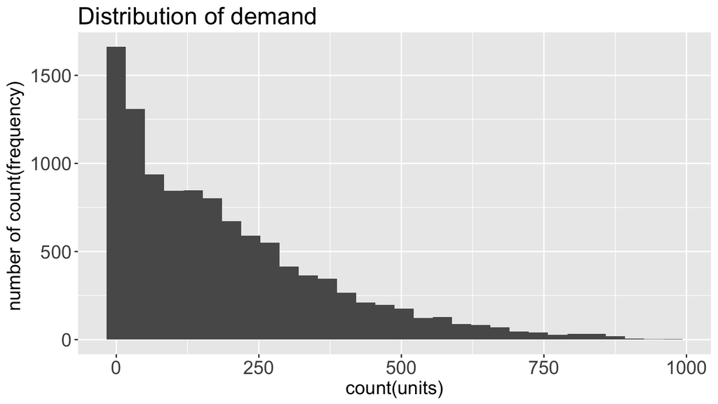

We first looked at the distribution of bike rental demand throughout the day.We observe that demand for bike rentals varies throughout the days, where it peaks around the beginning of the day( 7 am and 8 am) and end of the day(5 pm and 6 pm) because these are the time people commute to and from work.

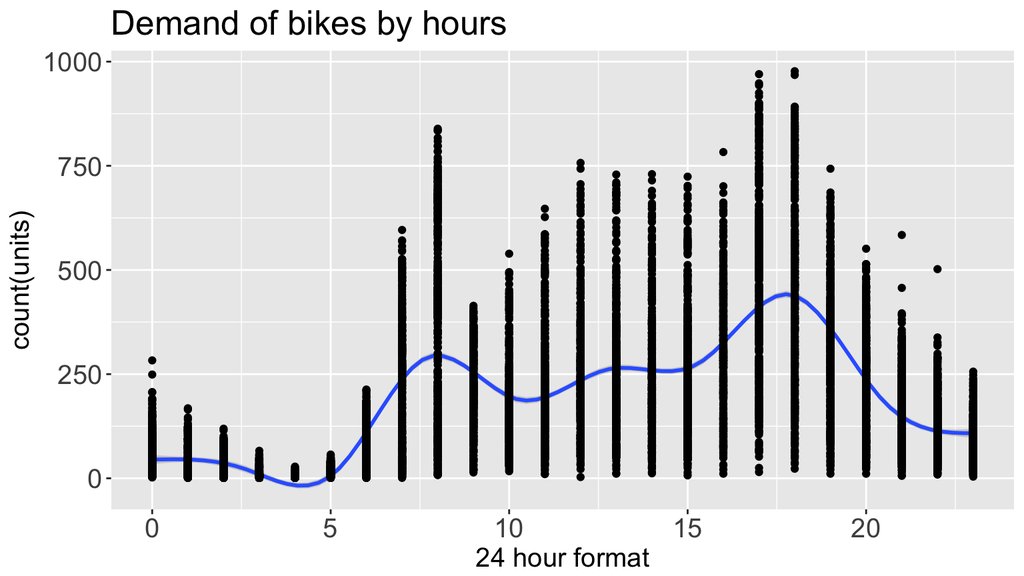

The next graph displays the demand of bike rentals over months.There is a curve where we see that the demand of bikes increases as month increases then decreases which can be related the warmer weather as the months change. In summer, people tend to bike more because the weather conditions are better.

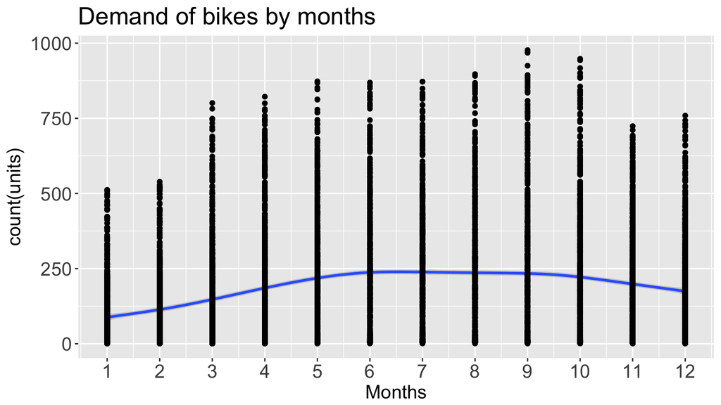

In addition, we look at the distribution of bike rentals in the four different given weather conditions. The median decreases as we go from Weather 1, a clear weather, to Weather 3 which is snowy. This is expected as less people are likely to bike as the weather conditions worsen. However, we have found that for Weather 4, the median was 164 as all 164 bikes were checked out within the same hour. We thought that this might be an input error. The mean followed the same pattern as the median. But we decided not to remove the 164 observations as removing them could give us incorrect results if this were not an input error and we have not yet decided on our predictor variables yet.

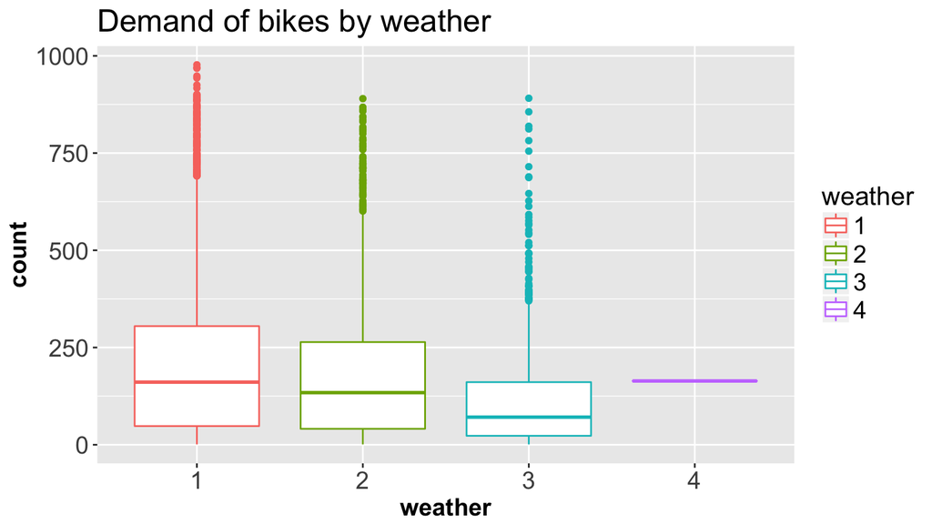

Next, we decided to look at correlation of the other variables with ‘Count.’ We have removed the ‘registered’ and ‘casual’ variables as they are not predictor variables of our test set. The top four are hour, temp, atemp and humidity. We next looked at the correlation between temp and atemp which was 0.98 and at the absolute difference between them. Most of the observations had a difference which was less than six degrees. We concluded that having both temp and atemp would not yield the best result as one variable would capture most of the variation in Count, making the other variable not significant.

So, for our final model, we decided to use temperature, humidity and hour since they are the variables correlating the highest with count. And for temperature we decided to go with temp because people usually look at the temperature forecast beforehand. Bikers are likely to look at temperature of the day before deciding to rent a bike or not. Humidity also plays an important factor. We found that high humidity discourages bike rentals. And hour is also an important factor as bike rentals are likely to be influenced by commuting hours and biking for leisure. That is why we believe these three predictor variables will yield the best model to predict bike rentals.

Table with highest correlations with Count

| Count | Other variables | correlation |
| --- | --- | --- |
| count | hour | 0.4006012 |
| count | temp | 0.3944536 |
| count | atemp | 0.3897844 |
| count | humidity | -0.3173715 |

# Model Fit

$$\widehat{Count} = \widehat{\beta_0} + \widehat{\beta_1} \ \ temperature + \widehat{\beta_2} \ \ humidity + \widehat{\beta_3} \ \ hour$$

# Create Submission File

On submitting our prediction on Kaggle, we got a score of 1.21517 where the score represents the Root Mean Squared Logarithmic Error (RMSLE).

# Resources

- Package ‘lubridate’ [documentation](https://cran.r-project.org/web/packages/lubridate/lubridate.pdf)